# An example to compute Fisher’s exact p-value and CI

Suppose we conduct experiment with complete randomization, obtain the assignment $W = (1,0,0,0,0,0,1,1)'$, and the observed outcome for all units are $Y^{\text{obs}} = (14, 6, 4, 5, 6, 7, 10, 9)'$.

- Impute all the missing potential outcomes under the sharp null hypothesis of no individual causal effects.

```r
W <- c(1,0,0,0,0,0,1,1)

Yobs <- c(14, 6, 4, 5, 6, 7, 10, 9)

# Under the sharp null of no causal effect
Y0 <- Y1 <- Yobs
```

- Assume the sharp null hypothesis of no individual causal effects. What is the distribution of the difference-in-means estimator $\hat{\tau}$.

```r
## observed test statistics value, here you can also replace the difference-in-means estimator with other types of test statistics
tau_obs <- mean(Yobs[W==1]) - mean(Yobs[W==0])

### get all possible assignments
treated_all = combn(8, 3)
W_all = matrix(0, nrow = 56, ncol = 8)
for(m in 1:56){
  W_all[m, treated_all[,m]] = 1
}
dim(W_all)
```

```
[1] 56  8
```

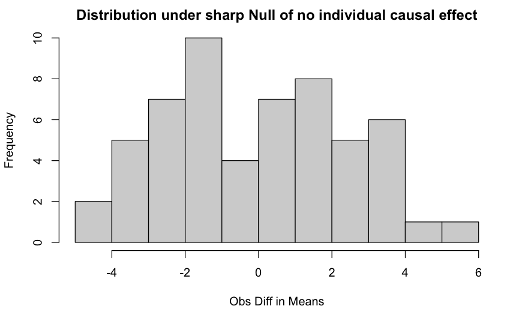

```r
tau_rand <- apply(W_all, 1, function(w) mean(Y1[w==1]) - mean(Y0[w==0]))
hist(tau_rand, breaks = 10, main="Distribution under sharp Null of no individual causal effect", xlab="Obs Diff in Means")
```

- How extreme is the observed difference-in-means estimator $\hat{\tau}^{\text{obs}}$? What is the probability of having at least as extreme as the observed one? More rigorously, specify your test statistic and report your randomization test $p$-value.

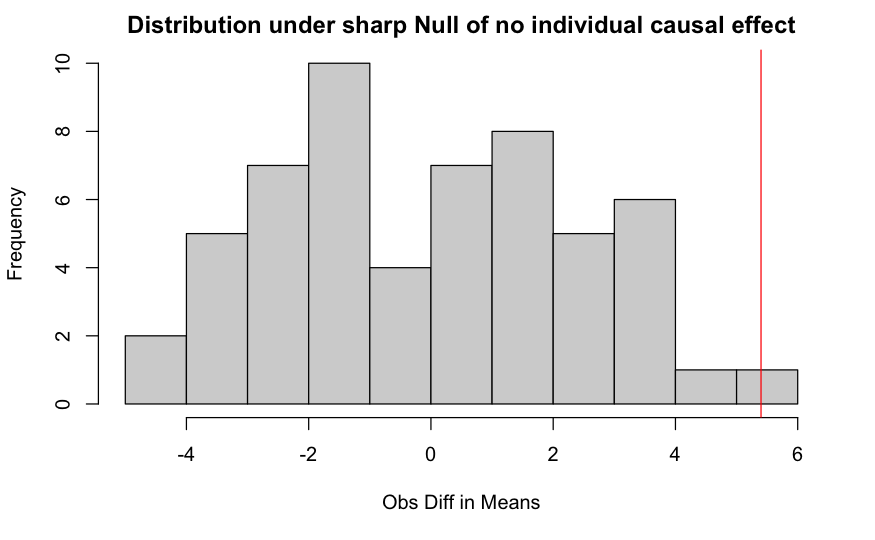

```r
hist(tau_rand, breaks = 10, main="Distribution under sharp Null of no individual causal effect", xlab="Obs Diff in Means")
abline(v = tau_hat, col = "red")
```

```r
## calculate p-value
p <- mean(abs(tau_rand) >= abs(tau_obs))
print(p)
```

```
[1] 0.01785714
```

- Obtain Fisher’s exact p-value under the sharp null hypothesis that the individual treatment effects are all 1.

```r
# Under the sharp null of causal effect is 1
Y0 <- Y1 <- rep(NA, length(Yobs))
Y0[W == 0] <- Yobs[W == 0]
Y0[W == 1] <- Yobs[W == 1] - 1

Y1[W == 1] <- Yobs[W == 1]
Y1[W == 0] <- Yobs[W == 0] + 1

## recompute the distribution of Y1[w = 1] - Y0[w = 0] - 1
tau_rand <- apply(W_all, 1, function(w) mean(Y1[w==1]) - mean(Y0[w==0]))
p = mean(abs(tau_rand - 1) >= abs(tau_obs - 1))
print(p)
```

```
[1] 0.01785714
```

- Calculate the randomization $p$-value for a sequence of sharp null hypotheses of additive treatment effects of $\{-20,-19, \ldots, 19,20\}$, and get the $95\%$ confidence interval

```r
# need to write a function that compute p-value for any tau
getPvalue <- function(tau, Yobs, W) {
  Y0 <- Y1 <- rep(NA, length(Yobs))
  Y0[W == 0] <- Yobs[W == 0]
  Y0[W == 1] <- Yobs[W == 1] - tau

  Y1[W == 1] <- Yobs[W == 1]
  Y1[W == 0] <- Yobs[W == 0] + tau

  ## recompute the distribution of Y1[w = 1] - Y0[w = 0] - 1
  tau_rand <- apply(W_all, 1, function(w) mean(Y1[w==1]) - mean(Y0[w==0]))
  p = mean(abs(tau_rand - tau) >= abs(tau_obs - tau))
  return(p)
}

## Compute the p-value for a seqeunce of tau
tau_seq <- seq(-20, 20, by = 1)
pvalue_seq <- sapply(tau_seq, getPvalue, Yobs, W)
names(pvalue_seq) <- tau_seq
print(pvalue_seq, digits = 3)
```

```
   -20    -19    -18    -17    -16    -15    -14    -13    -12    -11    -10     -9     -8     -7     -6     -5     -4     -3     -2     -1
0.0179 0.0179 0.0179 0.0179 0.0179 0.0179 0.0179 0.0179 0.0179 0.0179 0.0179 0.0179 0.0179 0.0179 0.0179 0.0179 0.0179 0.0179 0.0179 0.0179
     0      1      2      3      4      5      6      7      8      9     10     11     12     13     14     15     16     17     18     19
0.0179 0.0179 0.0357 0.1786 0.3929 0.8571 0.6964 0.3571 0.1429 0.0536 0.0357 0.0179 0.0179 0.0179 0.0179 0.0179 0.0179 0.0179 0.0179 0.0179
    20
0.0179
```

A rough 95% confidence interval is [2, 10]. You may want a more refined confidence interval by finding the cutoff that is close to 0.05.

```r
## find a better lower bound
tau_seq1 <- seq(2, 3, by = 0.1)
pvalue_seq1 <- sapply(tau_seq1, getPvalue, Yobs, W)
names(pvalue_seq1) <- tau_seq1
print(pvalue_seq1, digits = 3)
```

```
     2    2.1    2.2    2.3    2.4    2.5    2.6    2.7    2.8    2.9      3
0.0357 0.0357 0.0357 0.0357 0.0357 0.0357 0.0357 0.0357 0.0357 0.0357 0.1786
```

```r
## find a better upper bound

tau_seq2 <- seq(9, 10, by = 0.1)
pvalue_seq2 <- sapply(tau_seq2, getPvalue, Yobs, W)
names(pvalue_seq2) <- tau_seq2
print(pvalue_seq2, digits = 3)
```

```
     9    9.1    9.2    9.3    9.4    9.5    9.6    9.7    9.8    9.9     10
0.0536 0.0357 0.0357 0.0357 0.0357 0.0357 0.0357 0.0357 0.0357 0.0357 0.0357
```

A more refined 95% CI is [2.9, 9.1]

- When the sample size is large, it is impossible to enumerate all possible randomizations. How would you get an approximation for the randomization test $p$-value?

```r
## Say we want M = 10000 random samples of the treatment assignments
### get M random samples of possible assignments
getPvalueMC <- function(tau, Yobs, W, M) {
  Y0 <- Y1 <- rep(NA, length(Yobs))
  Y0[W == 0] <- Yobs[W == 0]
  Y0[W == 1] <- Yobs[W == 1] - tau

  Y1[W == 1] <- Yobs[W == 1]
  Y1[W == 0] <- Yobs[W == 0] + tau

  ## recompute the distribution of Y1[w = 1] - Y0[w = 0] - 1
  tau_rand <- apply(W_all, 1, function(w) mean(Y1[w==1]) - mean(Y0[w==0]))

  set.seed(0)
  tau_rand <- sapply(1:M, function(i) {
    w <- sample(W)
    return(mean(Y1[w==1]) - mean(Y0[w==0]))
  })
  p = mean(abs(tau_rand - tau) >= abs(tau_obs - tau))
  return(p)
}

getPvalueMC(0, Yobs, W, 10000)
```

```
[1] 0.0171
```